# Introductory Statistics with R

## Outline

1. R in Courses at Cal Poly
2. Advantages
3. Challenges
4. Lab Assignments
5. Shiny Pre-Lab Exercises
6. Student Outcomes
7. Take-Home Messages

## Courses with R at Cal Poly

- Stat 331: Statistical Computing with R
- Upper-level Stat Courses: Most profs use R
- Introductory “service” courses for non-majors
  - No CS or Stat background or prereqs
  - No Disagreement: Software should be used
  - Debatable: R should be used
  - Unpopular: Students should write code

## Advantages of Coding in Intro Classes

## Pedagogical:

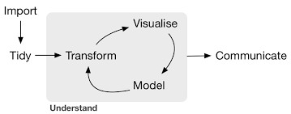

NOT

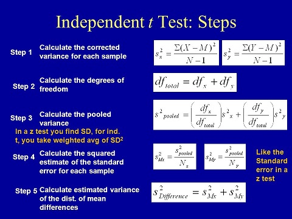

## Conceptual:

“Imagine that you calculate a sample mean for a population…”

VERSUS

```r
head(iris$Sepal.Length)
```

```
## [1] 5.1 4.9 4.7 4.6 5.0 5.4
```

```r
mean(iris$Sepal.Length)
```

```
## [1] 5.843333
```

## Real-world relevance:

[figure not shown]

## Challenges

## Pedagogical:

How to involve coding in teaching…  
…without teaching coding

```
"Why are we learning this if it's not on the test?"

  - Several students
```

## Logistical: Installation and File Management

“Where is my downloads folder?” - Generation Z, ages 17-23

[figure not shown]

## Motivational: Stats are scary! Code is scary!

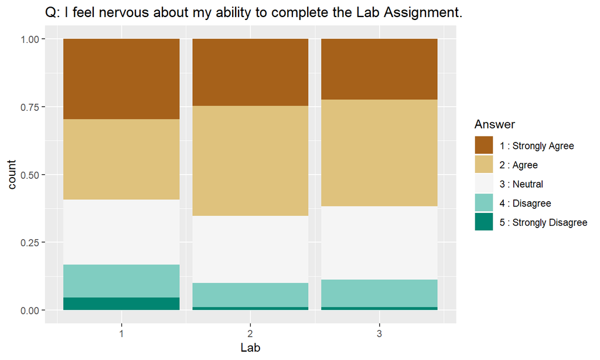

(Stat 218, Fall 2018)

## A few great resources

Great helper resources:

- Cloud servers:
  - RStudio Cloud + RStudio Connect
  - Amazon Web Services
  - University hosted servers
- Notebooks (Markdown, Jupyter)
- GitHub Classroom
- `usethis` and other helper packages

## Lab Assignments

## Example: Wine data

```r
str(wine)
```

```
## 'data.frame':    81 obs. of  12 variables:
##  $ fixed.acidity       : num  7.4 5.7 8.8 4.6 8.3 8.3 5 9.2 7.6 7.3 ...
##  $ volatile.acidity    : num  0.59 1.13 0.61 0.52 0.675 0.625 1.02 0.52 0.68 0.55 ...
##  $ citric.acid         : num  0.08 0.09 0.3 0.15 0.26 0.2 0.04 1 0.02 0.03 ...
##  $ residual.sugar      : num  4.4 1.5 2.8 2.1 2.1 1.5 1.4 3.4 1.3 1.6 ...
##  $ chlorides           : num  0.086 0.172 0.088 0.054 0.084 0.08 0.045 0.61 0.072 0.072 ...
##  $ free.sulfur.dioxide : int  6 7 17 8 11 27 41 32 9 17 ...
##  $ total.sulfur.dioxide: int  29 19 46 65 43 119 85 69 20 42 ...
##  $ density             : num  0.997 0.994 0.998 0.993 0.998 ...
##  $ pH                  : num  3.38 3.5 3.26 3.9 3.31 3.16 3.75 2.74 3.17 3.37 ...
##  $ sulphates           : num  0.5 0.48 0.51 0.56 0.53 1.12 0.48 2 1.08 0.48 ...
##  $ alcohol             : num  9 9.8 9.3 13.1 9.2 9.1 10.5 9.4 9.2 9 ...
##  $ quality             : int  0 0 0 0 0 0 0 0 0 0 ...
```

## V1: I supply the code

Do a hypothesis test at the 0.05 level, to see if the bad wines and good wines have the same pH level or not. What do you conclude?

```r
t.test(pH ~ quality, data = wine, alternative = "two.sided")
```

```
##
##  Welch Two Sample t-test
##
## data:  pH by quality
## t = 2.2403, df = 24.881, p-value = 0.03425
## alternative hypothesis: true difference in means is not equal to 0
## 95 percent confidence interval:
##  0.009404163 0.224405360
## sample estimates:
## mean in group 0 mean in group 1
##        3.384127        3.267222
```

## V2: Reproduce my process

Do a hypothesis test at the 0.05 level, to see if the bad wines and good wines have the same pH level or not. What do you conclude?

```r
t.test(pH ~ quality, data = wine, alternative = "two.sided")
```

Do a t-test comparing `density` across good and bad wines at the 0.05 level.

```r
### YOUR CODE HERE
```

## V3: Students as statisticians

Choose three chemical attributes of wine that you are interested in.  
For each of your chosen chemical properties, perform an appropriate hypothesis test to compare good and bad wines.  
Discuss each of the tests - what do you conclude about these chemical properties?

## Shiny Pre-Lab Exercises

```
"Tools for learning statistics vs. Tools for doing statistics:

We need a bridge between the two"

  - Amelia McNamara, ICOTS 2018
```

## Principles

A tool to ease the transition for beginners should…

1. Produce real and interesting data results without advance training, like an applet.
2. Require students to generate queries, not simply select from options, like true coding.
3. Make clear what is a built-in function and what input they get to choose.
4. Link concepts and questions from class to digital input/output.

## Student Outcomes

## Students recognize applicability

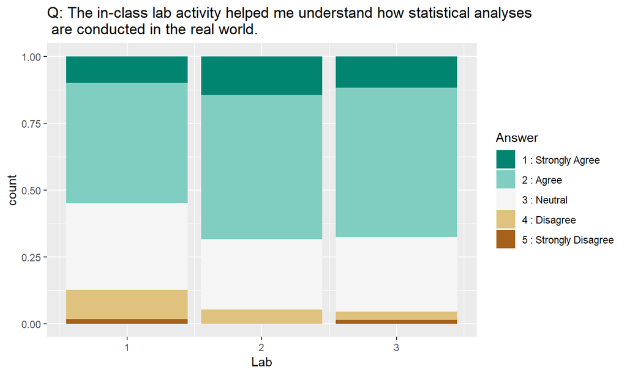

(Stat 218, Fall 2018)

## Students recognize value

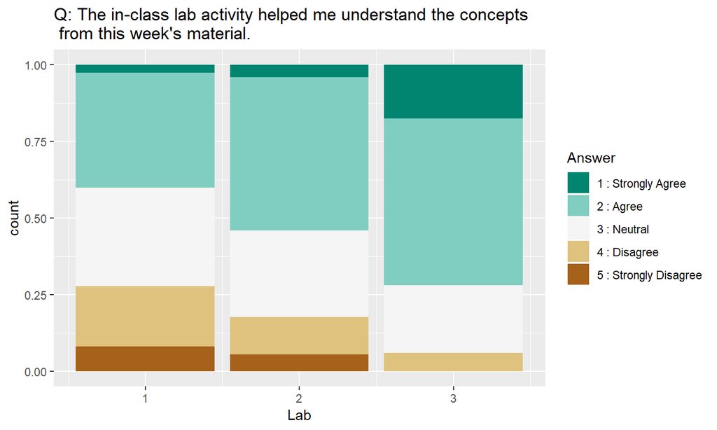

(Stat 218, Fall 2018)

## Students are proud of their work

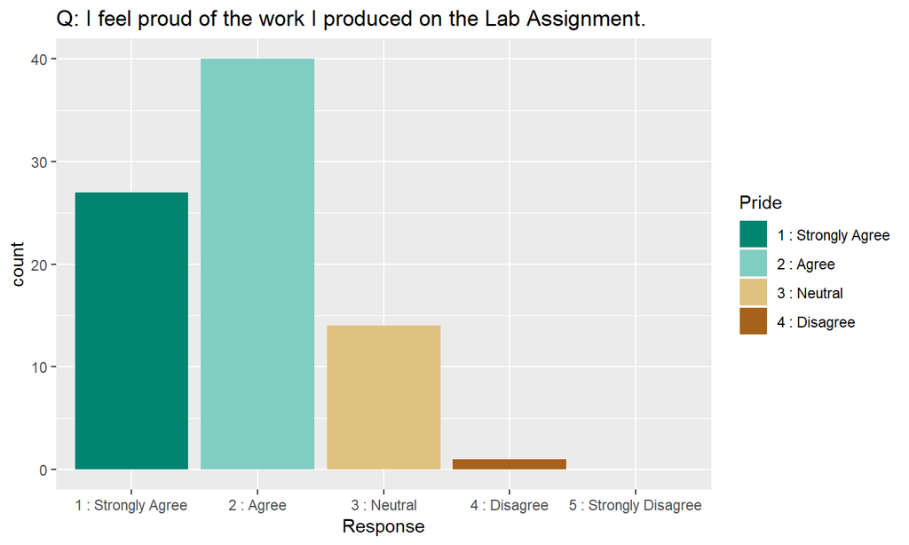

(Stat 218, Fall 2018)

## Students gained skills

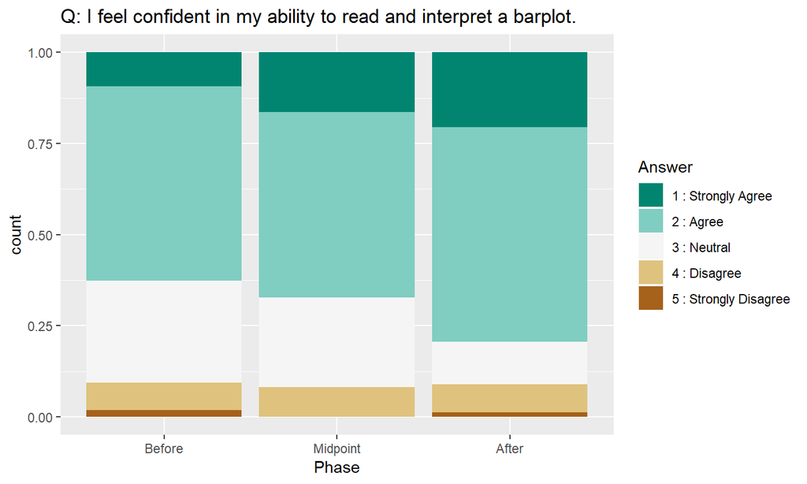

(Stat 218, Fall 2018)

## Exercises helped the transition to labs

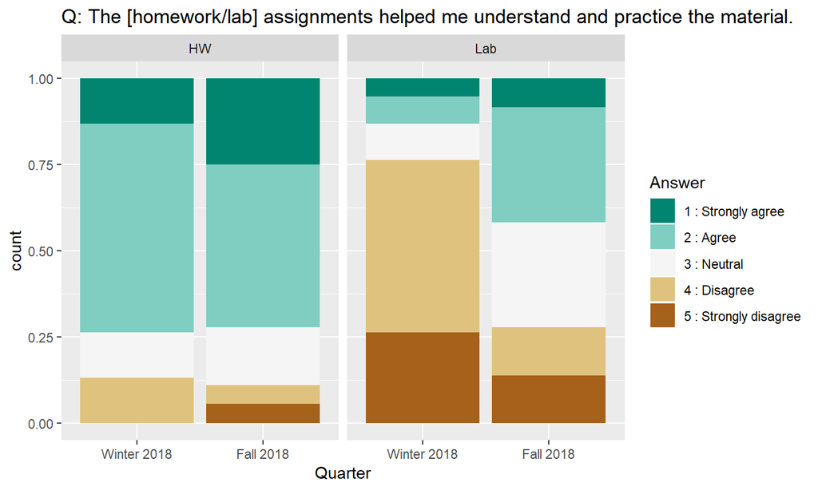

(Stat 218)

## Take-Home Messages

## What worked

- Students left class with the ability to actually analyze data from scratch.
- Anecdotally: deeper understanding of *some* concepts.
- Student satisfaction with tangible results.

## What needs work

- Encouraging thinking through code versus guess-and-check with copy-paste.
- Motivating the need for coding to the *students*

(Disconnect between class time allocation and tested material.)

- Logistics of creating/hosting exercises: {demoR} and {shindig}!

## Advice

- Growing pains and logistical headache are worth it.
- Introductory, non-major students *can* handle R!

[figure not shown]

## My unpopular opinion

Computing isn’t a supplement to the material; it *is* the material.

If we aren’t teaching them to think computationally, we aren’t actually teaching them statistics.

## Final pitch:

```
"Not all statisticians should be coders,
but all statisticians should code."

  - Hadley Wickham, ICOTS 2018
```

Coming soon:

- {demoR} (JSM 2019)
- {shindig} (Fall 2019?)

## Thank you!

Slides: [github.com/kbodwin/Talks-and-Presentations/](https://github.com/kbodwin/Talks-and-Presentations/tree/master/SDSS_2019)

Find this project:  
github.com/kbodwin/Introductory-Statistics-Labs

Try a lab:  
[https://kbodwin.shinyapps.io/CatVars2](https://kbodwin.shinyapps.io/Lab_Exercise_CatVars2)  
https://kbodwin.shinyapps.io/Lab_Exercise_tDist  
[https://kbodwin.shinyapps.io/t_tests2](https://kbodwin.shinyapps.io/Lab_Exercise_t_tests2)

Contact:  
kbodwin@calpoly.edu  
calpoly.edu/~kbodwin  
@kellybodwin